# Тесты

```python
import os
str="explorer"
str+=" C:\Program Files (x86)\GitExtensions\GitExtensions.exe"
os.system(str)
```

```
1
```

```python
import os
str="start https://lms.netacad.com/course/view.php?id=563546"
os.system(str)
```

```
0
```

# Тесты 6/14

# Глава 1. Контрольная работа

Какой порт позволяет передавать видео высокой четкости по протоколу DisplayPort? Выберите один ответ:

- DVI
- VGA
- RCA
- +Thunderbolt

Как внутренние компоненты компьютера защищаются от электростатических разрядов? Выберите один ответ:

- +заземление внутренних компонентов посредством присоединения их к корпусу
- использование нескольких вентиляторов для разгона теплого воздуха по корпусу
- использование корпусов компьютеров, изготовленных из пластика или алюминия
- отключение компьютера от сети после использования

Какие два компонента ПК связываются с ЦП через набор микросхем «Южный мост»? (Выберите два варианта.) Выберите один или несколько ответов:

- +жесткий диск
- ОЗУ
- +64-разрядный гигабитный адаптер Ethernet
- видеоплата

Какой форм-фактор материнской платы имеет самый маленький размер, чтобы его можно было использовать в клиентских устройствах? Выберите один ответ:

- Micro-ATX
- ATX
- +Mini-ATX
- ITX

Какие устройства являются устройствами вывода? (Выберите три варианта). Выберите один или несколько ответов:

- мышь
- +наушники
- клавиатура
- +монитор
- дактилоскопический сканер
- +принтер

[figure not shown]

Посмотрите на изображение. Какой тип разъема изображен? Выберите один ответ:

- Адаптер Molex-SATA
- Адаптер DVI-HDMI
- Адаптер USB-PS/2
- +Конвертер HDMI-VGA

Технический специалист хочет заменить вышедший из строя блок питания на высокопроизводительном игровом компьютере. Какой форм-фактор должен подобрать технический специалист? Выберите один ответ:

- AT
- +EPS12V
- ATX
- ATX12V

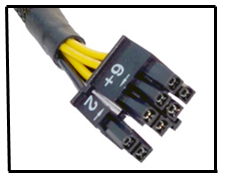

Посмотрите на изображение. Для чего этот разъем используется в ПК? Выберите один ответ:

- для подключения оптических дисков
- +для подачи питания к разным внутренним компонентам
- для подключения устаревших гибких дисков
- для подключения накопителей

Какой тип диска содержит магнитный жесткий диск со встроенной флэш-памятью, служащей энергонезависимым кэшем? Выберите один ответ:

- SSD
- NVMe
- SCSI
- +SSHD

Устройство ввода какого типа позволяет идентифицировать пользователей по голосу? Выберите один ответ:

- Графический планшет
- Сканер
- +Устройство биометрической идентификации
- KVM-переключатель

Какое действие может снизить риск поражения ЭСР при работе с компьютерным оборудованием? Выберите один ответ:

- подключение компьютера к устройству защиты от скачков напряжения
- перемещение беспроводных телефонов за пределы рабочего места
- снижение уровня влажности на рабочем месте
- +работа на заземленном антистатическом коврике

Какой слот расширения используется в устройствах с поддержкой NVMe? Выберите один ответ:

- SATA
- PCI
- USB-C
- +PCIe

В ведении сетевого администратора на данный момент находится три сервера, и ему нужно добавить четвертый, однако для размещения дополнительного монитора и клавиатуры недостаточно места. При помощи какого устройства можно подключить все серверы к одному комплекту монитора и клавиатуры? Выберите один ответ:

- коммутатора USB
- +KVM-переключателя
- концентратора PS/2
- монитора с сенсорным экраном
- ИБП

Какое утверждение описывает технологию дополненной реальности (ДР)? Выберите один ответ:

- +Накладывает изображения и аудио на реальный мир в реальном времени.
- Всегда необходима гарнитура.
- Гарнитура плотно скрывает естественное освещение.
- Не предоставляет пользователям немедленный доступ к информации об их реальном окружении.

# Глава 2. Контрольная работа

Что следует сделать перед установкой ОЗУ на материнскую плату? Выберите один ответ:

- Прежде чем установить модуль ОЗУ, убедиться, что замки гнезд расширения памяти находятся в закрытом положении.
- Изменить положение переключателя напряжения в соответствии с техническими характеристиками ОЗУ.
- В первую очередь заполнять центральные разъемы.
- +Убедиться, что ОЗУ совместимо с материнской платой, просмотрев документацию к ней или веб-сайт изготовителя.

Технический специалист должен приобрести новый адаптер для компьютера. Какой тип адаптера следует приобрести с учетом необходимости обработки цифровых сигналов? Выберите один ответ:

- +звук
- хранение
- графика
- сбор

Какой форм-фактор внутреннего жесткого диска SATA чаще всего используется в системных блоках? Выберите один ответ:

- 2,25 inch (5,7 cm)
- 5,25 inch (13,3 cm)
- +3,5 inch (8,9 cm)
- 2,5 inch (6,4 cm)

[figure not shown]

Посмотрите на изображение. Специалист устанавливает второй жесткий диск SATA. Какая секция материнской платы будет использоваться для подключения кабеля SATA?

Выберите один ответ:

- +секция B
- секция A
- секция C
- секция D

- кнопка питания
- +USB
- световой индикатор питания
- светодиодный индикатор активности драйвера

Верно или нет утверждение? Устанавливая жесткий диск, рекомендуется сначала крепко затянуть винты диска вручную, а затем при помощи отвертки. Выберите один ответ:

- +верно
- неверно

Специалист, собирающий персональный компьютер, заказал следующие детали: 1 - AMD 3,7 ГГц 2 - Gigawhiz GA-A239VM (не оборудован разъемами USB 3.1 на передней панели) 3 - HorseAir DDR3 8 Гб 4 - ATX с тремя отсеками для дисков 3.5" 5 - Eastern Divide 1TB 7200 RPM 6 – Zoltz 550W

Что означает 550W в 6-ом пункте (Zoltz 550W)? Выберите один ответ:

- скорость ОЗУ
- +выходная мощность
- входная мощность
- скорость материнской платы

Назовите две причины, по которым может потребоваться обновить сетевую плату. (Выберите два варианта.) Выберите один или несколько ответов:

- импорт видео
- установка RAID
- +обеспечение подключения к беспроводной сети
- увеличение интервала выборки
- +увеличение полосы пропускания

Какой тип носителя является устаревшим, но по-прежнему используется в видеокамерах? Выберите один ответ:

- xD
- MicroSD
- +CompactFlash
- MiniSD

Прежде чем начать работу с компьютером, что должен сделать технический специалист? Выберите один ответ:

- Проверить, что окружающая среда потенциально безопасна.
- Проверить, что на компьютере нет вирусов.
- +Снять с себя часы и ювелирные украшения.
- Отсоединить все провода кроме кабеля питания.

Специалиста попросили передвинуть тяжелый промышленный принтер. Какую технику безопасности необходимо соблюдать в этой ситуации? Выберите один ответ:

- Надеть защитные очки.
- Перед тем, как передвинуть принтер, вынуть из него бумагу и все емкости с чернилами.
- +Согнуть колени, поднимая принтер.
- Использовать поднимающее устройство.

Каким образом можно модернизировать аппаратное обеспечение, чтобы добавить больше памяти в современный смартфон? Выберите один ответ:

- CompactFlash
- +MicroSD
- жесткий диск
- флеш-диск USB

Какая плата адаптера в ПК обеспечивает отказоустойчивость данных? Выберите один ответ:

- +плата RAID
- плата захвата
- плата ввода-вывода
- карта SD

Что необходимо знать перед тем, как выбирать блок питания? (Выберите два варианта.) Выберите один или несколько ответов:

- +общая мощность всех компонентов
- требования к напряжению периферийных устройств
- установленная операционная система
- тип ЦП
- +форм-фактор корпуса

# Глава 3. Контрольная работа

Какое обновление оборудования позволит процессору игрового ПК обеспечивать оптимальный уровень производительности для видеоигр? Выберите один ответ:

- диск EIDE с высоким быстродействием
- жидкостное охлаждение
- внешний жесткий диск большой емкости
- +быстрое ОЗУ большого объема

Какой признак может указывать на низкий уровень заряда батареи CMOS? Выберите один ответ:

- Во время процедуры POST воспроизводится звуковой код ошибки.
- Компьютер не загружается.
- Низкая скорость доступа к файлам на жестком диске.
- +Дата и время на компьютере указаны неправильно.

Какой специальный компонент компьютера наиболее важен для рабочей станции, предназначенной для работы с аудио и видео? Выберите один ответ:

- плата ТВ-тюнера
- высокоскоростной адаптер беспроводного доступа
- жидкостная система охлаждения ЦП
- +специальная видеокарта

Какое устройство может защитить компьютер от провалов напряжения, обеспечивая постоянный уровень электрической мощности? Выберите один ответ:

- +ИБП
- адаптер переменного тока
- сетевой фильтр
- система аварийного электропитания

Технический специалист случайно пролил чистящий раствор на пол рабочего помещения. Где он может найти инструкции по удалению и утилизации данного продукта? Выберите один ответ:

- в страховой политике компании
- +в сертификате безопасности
- в нормативах, предоставляемых местной администрацией по охране труда и технике безопасности
- у местной группы по обращению с опасными материалами

Какие единицы используются при измерении величины сопротивления току в цепи? Выберите один ответ:

- вольты
- амперы
- +омы
- ватты

На каком веб-сайте следует искать инструкцию по обновлению BIOS на компьютере? Выберите один ответ:

- на сайте изготовителя корпуса
- на сайте разработчика операционной системы
- на сайте изготовителя ЦП
- +на сайте изготовителя материнской платы

Что из нижеперечисленного относится к приемам увеличения производительности процессора по сравнению с фабричным значением? Выберите один ответ:

- ограничение
- +разгон
- гиперпоточность
- многозадачность

Укажите определение термина «разгон». Выберите один ответ:

- +увеличение тактовой частоты ЦП выше рекомендованных производителем значений
- изменение тактовой частоты шины материнской платы для повышения производительности присоединенных адаптеров
- модификация тактового генератора материнской платы с целью увеличения сигналов синхронизации
- замена медленного синхронного динамического ОЗУ (SDRAM) памятью более высокого быстродействия

Какие два параметра можно изменить в программе настройки BIOS? (Выберите два варианта.) Выберите один или несколько ответов:

- размер файла подкачки
- драйверы устройств
- +включение и выключение устройств
- размер разделов диска
- +порядок загрузки

Где хранятся настройки BIOS? Выберите один ответ:

- ОЗУ
- жесткий диск
- кэш
- +CMOS

Какую характеристику имеют тонкие клиенты? Выберите один ответ:

- Они способны одновременно запускать несколько операционных систем.
- Они выполняют все задачи обработки локально.
- Им требуется быстрое ОЗУ большого объема.
- +Для доступа к вычислительным ресурсам и хранилищу им требуется сетевое соединение.

Сетевой администратор настраивает веб-сервер для небольшой рекламной компании и его волнует вопрос доступности данных. Администратор хочет обеспечить безотказную работу дисков с использованием минимального числа дисков. Какой уровень RAID-массива должен выбрать администратор? Выберите один ответ:

- RAID 5
- +RAID 1
- RAID 6
- RAID 0

На материнскую плату установлен ЦП с функцией гиперпоточности (HyperThreading). Сколько инструкций он может выполнять одновременно? Выберите один ответ:

- 6
- 2
- 8
- +4

# Глава 4. Контрольная работа

Какова самая главная причина, по которой компаниям следует проводить профилактическое обслуживание компьютеров? Выберите один ответ:

- +Профилактическое обслуживание помогает защитить компьютерное оборудование от проблем в будущем.
- Профилактическое обслуживание позволяет специалистам ИТ-отдела проводить регулярные проверки содержимого жестких дисков пользователей для контроля за соблюдением политик пользования компьютером.
- Профилактическое обслуживание позволяет ИТ-руководителям проверять местоположение и состояние компьютерных ресурсов.
- Профилактическое обслуживание предоставляет младшим инженерам возможность получить дополнительный опыт при отсутствии реальных угроз или проблем.

Какой этап процесса поиска и устранения неисправностей помогает избежать повторного выполнения ранее проведенных ремонтных работ? Выберите один ответ:

- выявление неисправности
- подготовка плана действий
- +документирование проблемы и ее решения
- внедрение решения

Какое средство необходимо использовать для удаления пыли с компонентов внутри корпуса компьютера? Выберите один ответ:

- +сжатый воздух
- влажную ткань
- щетку
- ватные палочки

Какие два последствия влечет за собой отсутствие плана профилактического обслуживания для пользователей и организаций? (Выберите два варианта.) Выберите один или несколько ответов:

- +Увеличение времени простоя.
- Рост потребности в документации.
- +Увеличение расходов на ремонт.
- Увеличение количества регулярных обновлений.
- Увеличение объема задач управления.

Какое действие должно выполняться в рамках профилактического обслуживания жесткого диска? Выберите один ответ:

- Продувка диска изнутри с помощью сжатого воздуха для удаления пыли.
- Очистка головок чтения и записи с помощью ватной палочки.
- +Проверка надежного подключения кабелей.
- Проверка свободного вращения диска.

Какой порядок рекомендуется при очистке внутренних компонентов компьютера? Выберите один ответ:

- +Зафиксировать вентилятор ЦП, чтобы предотвратить его вращение, и продуть вентилятор сжатым воздухом.
- Перевернуть баллон со сжатым воздухом во время распыления.
- Очистить головки жесткого диска ватным тампоном.
- Извлечь ЦП перед очисткой.

Какое действие в процессе устранения неполадок следует выполнить после выявления проблемы? Выберите один ответ:

- Документирование результатов.
- Проверка решения.
- Применение решения.
- Определение точной причины.
- +Выработка предположений относительно возможных причин.

Члены научной экспедиции используют в своей работе ноутбуки. Температура окружающей среды, в которой работают ученые, варьируется от -25 до +27 градусов по Цельсию. Уровень влажности составляет около 40 процентов. Уровень шума низкий, но местность неровная, а скорость ветра может достигать 20 м/с (72 км/ч). Данные в ноутбук ученые вводят на привале. Какое из перечисленных условий, вероятнее всего, негативно повлияет на ноутбук? Выберите один ответ:

- влажность
- +температура
- ветер
- неровная местность

Сотрудник говорит, что для открытия большого файла документа требуется больше времени, чем обычно. Инженер службы поддержки настольных систем предполагает неисправность жесткого диска. Что должен сделать инженер? Выберите один ответ:

- Обратиться в компанию, оказывающую услуги по восстановлению данных.
- Заменить жесткий диск новым, чтобы определить точную причину неполадки.
- +Выполнить резервное копирование пользовательских данных с рабочей станции.
- Провести очистку диска.

Какая из перечисленных ниже процедур входит в плановое обслуживание аппаратных средств? Выберите один ответ:

- Выбор оптимального разрешения на мониторе.
- Удаление пыли из корпуса жесткого диска.
- Обновление файлов определений вирусов.
- Обзор обновлений безопасности.
- +Проверка и закрепление плохо подключенных кабелей.

Пользователь открыл заявку, указывающую, что часы компьютера все время показывают неправильное время. Укажите наиболее вероятную причину. Выберите один ответ:

- Кристалл тактового генератора материнской платы поврежден.
- +Неправильная установка или отказ батареи CMOS.
- Требуется разогнать ЦП.
- Требуются исправления операционной системы.

Заказчик сообщает о том, что недавно ему не удалось открыть несколько файлов. Специалист по обслуживанию решает проверить состояние жесткого диска и структуру файловой системы. Он спрашивает заказчика, выполнялось ли резервное копирование диска, заказчик сообщает, что неделю назад выполнялось резервное копирование в другой логический раздел диска. Что специалисту по обслуживанию следует сделать перед выполнением диагностических процедур на этом диске? Выберите один ответ:

- Выполнить восстановление файла из существующей резервной копии в логическом разделе.
- Установить новый жесткий диск в качестве основного диска и сделать текущий диск подчиненным.
- +Выполнить резервное копирование данных пользователя на съемный носитель.
- Запустить служебную программу CHKDSK.

Что свидетельствует о неисправности блока питания? Выберите один ответ:

- Не удается надлежащим образом подсоединить кабель питания к блоку питания и/или электрической розетке.
- +Иногда компьютер не включается.
- На компьютере выводится код ошибки самотестирования при включении питания (POST).
- На экране отображается только мигающий курсор.

Какую задачу необходимо решить, прежде чем эскалировать проблему (передать проблему специалисту по поддержке более высокого уровня)? Выберите один ответ:

- +Задокументировать каждый проведенный тест.
- Попросить заказчика создать новый запрос на поддержку.
- Заменить все аппаратные компоненты на заведомо работоспособные.
- Повторно провести каждый тест, чтобы убедиться в точности результатов.

# Глава 5. Контрольная работа

Какие два основных носителя используются в сетях? (Выберите два варианта.) Выберите один или несколько ответов:

- дерево
- +волокно
- нейлон
- вода
- +медь

Какая сетевая служба автоматически назначает IP-адреса устройствам в сети? Выберите один ответ:

- Telnet
- DNS
- +DHCP
- traceroute

Какая технология обеспечения безопасности используется для пассивного изучения ⁪сетевого трафика с целью обнаружения возможной атаки? Выберите один ответ:

- +IDS
- прокси-сервер
- IPS
- межсетевой экран

Какие три стандарта Wi-Fi работают в диапазоне частот 2,4 ГГц? (Выберите три варианта.) Выберите один или несколько ответов:

- +802.11g
- +802.11b
- +802.11n
- 802.11a
- 802.11ac

Какая технология для умного дома требует использования устройства, называемого координатором, для создания беспроводной сети PAN? Выберите один ответ:

- Z-Wave
- 802.11n
- 802.11ac
- +Zigbee

Технического специалиста попросили помочь с подключением проводов для локальной сети LAN. Какие два стандарта должен изучить специалист, прежде чем приступать к проекту? (Выберите два варианта.) Выберите один или несколько ответов:

- Z-Wave
- 802.11n
- +T568B
- Zigbee
- 802.11c
- +T568A

Технический специалист должен выявить в сети пакеты, которые медленно выполняются при входе в Интернет. Порт под каким номером должен проверить специалист, чтобы обнаружить HTTP-пакеты? Выберите один ответ:

- 53
- 20
- 110
- +80
- 21

Какой тип сети имеет небольшую зону действия и служит для подключения принтеров, мышей и клавиатур к отдельному узлу? Выберите один ответ:

- беспроводная локальная сеть (WLAN)
- +персональная сеть (PAN)
- муниципальная сеть (MAN)
- локальная сеть (LAN)

Компания готовится к расширению за пределы своей страны. Все филиалы должны быть постоянно подключены к главному офису корпорации. Какая сеть для этого понадобится? Выберите один ответ:

- Беспроводная локальная сеть (WLAN)
- Локальная сеть (LAN)
- Муниципальная сеть (MAN)
- +Глобальная сеть (WAN)

Какое сетевое устройство воспроизводит сигнал данных без сегментации сети? Выберите один ответ:

- +концентратор
- маршрутизатор
- коммутатор
- модем

Какие два протокола работают на транспортном уровне модели TCP/IP? (Выберите два варианта.) Выберите один или несколько ответов:

- FTP
- IP
- +TCP
- ICMP
- +UDP

Какая технология использует существующую электрическую схему для подключения устройств к сети? Выберите один ответ:

- +Ethernet over Power
- 802,11
- IPS
- Z-Wave

# Глава 6. Контрольная работа

На малом предприятии используется веб-сервер; проводную и беспроводную сеть предприятия обслуживает беспроводной маршрутизатор Linksys WRT300N. Какая функция межсетевого экрана позволит клиентам предприятия обращаться к веб-серверу удаленно? Выберите один ответ:

- +перенаправление портов
- фильтрация MAC-адресов
- WPA2
- WEP
- включение портов

Какой протокол используется командой ping для проверки подключения между узлами сети? Выберите один ответ:

- ARP
- TCP
- +ICMP
- DHCP

Инженер хочет обновить драйвер сетевого адаптера для компьютера. Где лучше всего искать новые драйверы для сетевого адаптера? Выберите один ответ:

- установочный носитель для Windows
- установочный носитель из комплекта поставки сетевого адаптера
- +веб-сайт изготовителя сетевого адаптера
- Центр обновления Windows
- веб-сайт Microsoft

Компьютеру был присвоен IP-адрес 169.254.33.16. Какая команда инициирует процесс запроса нового IP-адреса? Выберите один ответ:

- net computer
- nslookup
- tracert
- +ipconfig /release

Какой метод фильтрации использует IP-адреса для указания разрешенных устройств в вашей сети? Выберите один ответ:

- черные списки
- фильтрация MAC-адресов
- запуск портов
- +белые списки
- переадресация портов

Какая проблема может возникнуть, если компьютер автоматически настраивает IP-адрес в диапазоне адресов 169.254.x.x? Выберите один ответ:

- +DHCP-сервер недоступен.
- На компьютере неправильно настроен шлюз по умолчанию.
- DNS-сервер недоступен.
- Сетевая плата компьютера отключена.

К чему приведет неработоспособность серверов DHCP в сети? Выберите один ответ:

- Рабочим станциям назначаются IP-адреса в сети 10.0.0.0/8.
- Рабочим станциям назначается IP-адрес 127.0.0.1.
- +Рабочим станциям назначаются IP-адреса в сети 169.254.0.0/16.
- Рабочим станциям назначается IP-адрес 0.0.0.0.

Компьютеру назначен IP-адрес 169.254.33.16. Что можно сказать об этом компьютере, исходя из назначенного адреса? Выберите один ответ:

- Он может обмениваться данными по локальной сети, а также через Интернет.
- Его общедоступный IP-адрес преобразован в частный IP-адрес.
- +Он не может обмениваться данными за пределами собственной сети.
- Он может обмениваться данными с сетями внутри конкретной компании, сети которой разделены на подсети.

Пользователь сообщил о том, что не может получить доступ к корпоративному веб-серверу. Технический специалист убедился, что веб-сервер доступен по IP-адресу. Каковы две возможные причины проблемы? (Выберите два варианта.) Выберите один или несколько ответов:

- На рабочей станции указан неверный адрес шлюза по умолчанию.
- Сетевое подключение не работает.
- +На рабочей станции указан неверный адрес сервера DNS.
- Веб-сервер настроен неправильно.
- +На сервере DNS указана неверная информация о веб-сервере.

Какой протокол динамически назначает IP-адреса сетевым устройствам? Выберите один ответ:

- ICMP
- +DHCP
- DNS
- RARP
- TCP

Беспроводной маршрутизатор отображает, что на нём настроен IP-адрес 192.168.0.1. Что это может означать? Выберите один ответ:

- +На беспроводном маршрутизаторе по-прежнему настроен IP-адрес, устанавливаемый по умолчанию на заводе-изготовителе.
- На маршрутизаторе настроена и нормально работает функция динамического выделения IP-адресов.
- Беспроводной маршрутизатор настроен для использования частоты канала 1.
- На беспроводном маршрутизаторе не работает функция преобразования сетевых адресов (NAT).

С помощью какой команды можно устранить проблемы с разрешением доменных имен? Выберите один ответ:

- tracert
- $arp -a$
- get
- +nslookup

Устройству назначен IPv6-адрес 2001:0db8:cafe:4500:1000:00d8:0058:00ab/64. Какой идентификатор сети имеет устройство? Выберите один ответ:

- 2001:0db8:cafe:4500:1000:00d8:0058:00ab
- 1000:00d8:0058:00ab
- 2001
- +2001:0db8:cafe:4500
- 2001:0db8:cafe:4500:1000

В небольшом офисе установлена новая рабочая станция. Пользователь этой рабочей станции может напечатать документ на сетевом принтере, подключенном к локальной сети, но не может получить доступ в Интернет. Укажите возможную причину проблемы. Выберите один ответ:

- Неправильно задан IP-адрес сервера DHCP.
- +Неправильно задан IP-адрес шлюза.
- Не работает стек протокола TCP/IP.
- На рабочей станции настроен статический IP-адрес.

# Глава 7. Контрольная работа

Что используется для предоставления смартустройствам информации о местоположении? Выберите один ответ:

- координатор Zigbee
- +GPS
- электронная книга
- умный концентратор

Какая деталь ноутбука снимается, если нажать на защелки, удерживающие ее на месте? Выберите один ответ:

- устройство для чтения карт
- блок питания
- беспроводная антенна
- +SODIMM

Докладчик на конференции не может подключить ноутбук к дисплею через проектор и вызывает технического специалиста. Что должен сделать в первую очередь технический специалист? Выберите один ответ:

- Заменить проектор или предоставить альтернативу.
- Перезагрузить ноутбук.
- +Использовать клавишу Fn, чтобы вывести изображение на внешний дисплей.
- Подключить адаптер переменного тока к ноутбуку.

Какое утверждение о материнских платах для ноутбуков является верным? Выберите один ответ:

- Они взаимозаменяемы с большинством материнских плат для настольных компьютеров.
- +Формфактор может быть разным у разных производителей.
- Большинство изготавливается в формфакторе ATX.
- При их изготовлении используются стандартные формфакторы, поэтому их можно легко менять друг с другом.

Торговый представитель общается в командировке по сотовому телефону с коллегами в своем офисе и своими заказчиками, отслеживает образцы, совершает звонки по работе, регистрирует мили и скачивает/загружает данные, находясь в отеле. Каким способом лучше всего подключаться к Интернету с мобильного устройства, чтобы сократить затраты? Выберите один ответ:

- кабель
- сотовая линия связи
- Z-Wave
- DSL
- +Wi-Fi

Какой тип носителя нужно использовать с устройством считывания карт, подключенным к ноутбуку? Выберите один ответ:

- CD-R
- DVD
- Blu-ray
- +SD

Какие два источника информации используются для обеспечения геокэширования, геопривязки и отслеживания устройств на платформах Android и iOS? (Выберите два варианта.) Выберите один или несколько ответов:

- профиль пользователя
- положение относительно других мобильных устройств
- +сигналы GPS
- фотографии окружающей обстановки, сделанные встроенной камерой
- +сеть сотовой связи или Wi-Fi

В каком состоянии ACPI подает питание на ЦП и ОЗУ, но отключает питание неиспользуемых устройств? Выберите один ответ:

- S0
- S2
- +S1
- S4
- S3

Какой протокол позволяет скачивать почту с почтового сервера на клиент, а затем удалять эту почту с сервера? Выберите один ответ:

- +POP3
- HTTP
- IMAP
- SMTP

Какой компонент ноутбука использует регулирование частоты для сокращения энергопотребления и выделения тепла? Выберите один ответ:

- Жесткий диск
- Материнская плата
- +ЦП
- Оптический дисковод

Что означает аббревиатура CRU, когда речь идет о ноутбуке? Выберите один ответ:

- +деталь, которую может заменить пользователь
- сетевой разъем
- тип процессора
- тип устройства хранения

Технический специалист пытается определить причину проблем с ноутбуком. Что из нижеприведенного является примером проверки техническим специалистом своих предположений? Выберите один ответ:

- Специалист спрашивает у пользователя, когда тот впервые заметил эту проблему.
- Специалист подозревает, что проблема с подключением кабелей.
- +Специалист подключает ноутбук к сети с помощью адаптера питания переменного тока.
- Специалист определяет, что не работает клавиатура.

Какую технологию беспроводного доступа можно использовать для подключения беспроводных наушников к компьютеру? Выберите один ответ:

- Wi-Fi
- 4G-LTE
- NFC
- +Bluetooth

Почему модули памяти SODIMM хорошо подходят для ноутбуков? Выберите один ответ:

- Они не производят тепло.
- Они подключаются ко внешним портам.
- +Они имеют маленький форм-фактор.
- Они взаимозаменяемы с модулями памяти настольных ПК.

В каком типе дисплеев ноутбуков имеются компоненты, которые могут содержать ртуть и используют подсветку CCFL или LED? Выберите один ответ:

- на органических светодиодах
- +на жидких кристаллах
- плазма
- на светодиодах

# Глава 8. Контрольная работа

Какое программное обеспечение позволяет пользователям настраивать и изменять параметры принтера? Выберите один ответ:

- микропрограмма
- +ПО для настройки
- драйверы
- программы редактирования текстов

В чем заключаются два потенциальных недостатка отказа от использования расходных материалов принтера, рекомендованных изготовителем? (Выберите два варианта.) Выберите один или несколько ответов:

- Нерекомендованные компоненты может быть проще купить.
- +Возможно низкое качество печати.
- +Гарантия изготовителя может утратить силу.
- Нерекомендованные компоненты могут стоить дешевле.
- Возможно, потребуется более частая очистка принтера.

Устраняя неполадку принтера, инженер обнаруживает, что принтер был подключен к неправильному порту компьютера. Какую неполадку принтера вызвала эта ошибка? Выберите один ответ:

- Принтер печатает пустые страницы.
- На распечатанной странице документа присутствуют неизвестные символы.
- Диспетчер очереди печати отображает сообщение об ошибке.
- +Очередь печати работает, но задания печати не выполняются.

Инженер хочет организовать общий доступ к принтеру по сети, но согласно политике компании ни к какому компьютеру не разрешается напрямую подключать принтер. Какое устройство нужно инженеру? Выберите один ответ:

- USB-концентратор
- +аппаратный сервер печати
- коммутатор LAN
- док-станция

Каким способом рекомендуется очищать печатающие головки струйного принтера? Выберите один ответ:

- Использовать сжатый воздух.
- Протереть печатающие головки влажной тканью.
- +Использовать служебное ПО принтера.
- Протереть печатающие головки изопропиловым спиртом.

Какие два «закрытых» вопроса инженер может задать пользователю, пытаясь определить проблему с принтером? Выберите один или несколько ответов:

- Какие сообщения об ошибках отобразились на дисплее, когда возникла проблема?
- +Включено ли питание принтера?
- Что вы делали, когда возникла проблема?
- +Удается ли напечатать тестовую страницу на принтере?
- Какие изменения программного обеспечения или оборудования были сделаны на компьютере?

Сопоставьте общие параметры конфигурации принтера с соответствующими описаниями. (Не все варианты применимы.)

- +черно-белая печать - +используются только черные чернила
- +тип бумаги - +стандартная, для черновиков, глянцевая или фото
- +качество печати - +черновик, стандарт или фото
- +цветная печать - +используется несколько цветов
- +формат бумаги - +стандартная бумага, конверты или визитные карточки

Небольшая компания подключила несколько принтеров к Интернету при помощи Google Cloud Print. Мобильные сотрудники получили возможность распечатывать заказ-наряды, находясь в дороге. Использование какого типа принтера демонстрирует этот пример? Выберите один ответ:

- лазерный
- термографический
- струйный
- +виртуальный

Какое утверждение описывает процесс буферизации при печати? Выберите один ответ:

- +Документы большого размера временно сохраняются во внутренней памяти принтера, ожидая, когда он будет доступен для печати.
- ПК кодирует фотографию в язык, поддерживаемый принтером.
- Приложение выполняет подготовку документа для печати.
- Выполняется печать документа на принтере.

Для печати какого типа документов обычно требуется больше всего времени? Выберите один ответ:

- страницы текста высокого качества
- +цифровой цветной фотографии
- текста чернового качества
- чернового изображения фотографического качества

Небольшая компания думает, не заменить ли ей струйный принтер на лазерный. Назовите два недостатка лазерных принтеров. (Выберите два варианта.) Выберите один или несколько ответов:

- Печать только в черно-белом цвете.
- Использование дорогих пьезокристаллов для создания печатных изображений.
- Невозможна печать с высоким разрешением.
- +Дорогие картриджи с тонером.
- +Высокие первоначальные затраты.

В чем заключаются два недостатка предоставления общего доступа к принтеру, подключенному к компьютеру напрямую? (Выберите два варианта.) Выберите один или несколько ответов:

- Другие компьютеры не нужно подключать к принтеру напрямую.
- +Компьютер, напрямую подключенный к принтеру, всегда должен быть включен, даже если он не используется.
- Все компьютеры, использующие принтер, должны работать под управлением одной и той же операционной системы.
- Одновременно только один компьютер может использовать принтер.
- +Чтобы обеспечить общий доступ к принтеру, компьютеру приходится использовать собственные ресурсы для обработки заданий печати, поступающих на принтер.

Для оценки какой характеристики принтера используется количество точек на дюйм? Выберите один ответ:

- надежности
- стоимости владения
- +качества печати
- скорости

Как можно организовать совместное использование в одной сети локально подключенного принтера? Выберите один ответ:

- Удалить драйверы PS.
- +Включить общий доступ к принтеру.
- Установить общие драйверы PCL.
- Установить USB-концентратор.

Какой термин используется для описания двусторонней печати? Выберите один ответ:

- ИК-печать
- буферизация
- +дуплексная печать
- постановка в очередь

Что в первую очередь нужно сделать, выполняя профилактическое обслуживание принтера? Выберите один ответ:

- Отключить принтер от локальной сети.
- Вынуть бумагу из лотка принтера.
- Очистить печатающие головки при помощи служебного ПО принтера.
- +Отключить принтер от источника питания.

# Глава 9. Контрольная работа

В группе НИОКР работают сотрудники, находящиеся в разных офисах компании. Группа хочет создать централизованное хранилище файлов, чтобы хранить там документы, относящиеся к НИОКР. Назовите два возможных варианта. (Выберите два варианта.) Выберите один или несколько ответов:

- Gmail
- виртуальный рабочий стол
- +Google Диск
- +OneDrive
- Exchange Online

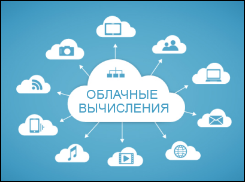

Какое понятие связано с облачными вычислениями? Выберите один ответ:

- Удаленные работники
- Беспроводные сети
- Высокие серверы
- +Виртуализация

Каким образом облачные вычисления повышают производительность и удобство пользователя в онлайн-версиях средств для эффективной работы в офисе? Выберите один ответ:

- подключение локальных аппаратных устройств, например принтера, к поставщику услуг
- обеспечение защищенного соединения между клиентом и поставщиком услуг
- скачивание пакета приложений в локальное хранилище
- +предоставление кода приложения при необходимости

ИТ-отдел одной компании ищет решение для объединения функциональности нескольких критически важных серверных компьютеров в ВМ на меньшем числе узловых компьютеров с большей производительностью. Какие два типа гипервизора можно рассмотреть? (Выберите два варианта.) Выберите один или несколько ответов:

- Windows 10 Hyper-V
- +VMware vSphere
- +Oracle VM Server
- Oracle VM VirtualBox
- VMWare Workstation

К какой категории гипервизоров принадлежит Microsoft Virtual PC? Выберите один ответ:

- Тип 3
- Тип 4
- Тип 1
- +Тип 2

Какой облачный сервис предоставляет компании возможность использования сетевого оборудования, такого как маршрутизаторы и коммутаторы? Выберите один ответ:

- ПО как услуга (SaaS)
- +инфраструктура как услуга (IaaS)
- беспроводная сеть как услуга (WaaS)
- браузер как услуга (BaaS)

Небольшая рекламная компания хочет отдать выполнение своих ИТ-задач на аутсорс поставщику облачных сервисов. Эти задачи включают обучение пользователей, лицензирование ПО и выделение ресурсов. Какой облачный сервис лучше всего приобрести этой компании? Выберите один ответ:

- инфраструктура как услуга (IaaS)
- платформа как услуга (PaaS)
- ПО как услуга (SaaS)
- +ИТ как услуга (IТaaS)

Какую характеристику имеет виртуальная машина на ПК? Выберите один ответ:

- Максимальное количество доступных виртуальных машин зависит от программных ресурсов хоста.
- Для подключения виртуальной машины к Интернету требуется отдельный физический сетевой адаптер.
- Виртуальная машина не подвержена угрозам и атакам вредоносного ПО.
- +Виртуальная машина работает под управлением собственной операционной системы.

Назовите два преимущества использования решения с исходным гипервизором вместо решения с гипервизором, размещенным на сервере, когда речь идет о крупных предприятиях, развертывающих виртуальные серверы. (Выберите два варианта.) Выберите один или несколько ответов:

- устранение необходимости в ПО консоли управления
- +прямой доступ к аппаратным ресурсам
- +повышение эффективности
- добавление дополнительного уровня абстракции
- повышение безопасности

Какое утверждение описывает характеристику облачных вычислений? Выберите один ответ:

- Компании могут подключаться непосредственно к Интернету без использования услуг интернет-провайдера.
- Для доступа к облачным сервисам требуется вложение средств в новую инфраструктуру.
- Устройства могут подключаться к Интернету через существующие электрические кабели.
- +Доступ к приложениям можно получать через Интернет по подписке.

В чем разница между центром обработки данных и облачными вычислениями? Выберите один ответ:

- Для центров обработки данных необходимы облачные вычисления, но для облачных вычислений центры обработки данных не требуются.
- +Облачные вычисления предоставляют доступ к совместно используемым вычислительным ресурсам, а центр обработки данных представляет собой объект, на котором хранятся и обрабатываются данные.
- Между ними нет разницы. Эти понятия взаимозаменяемы.
- Из двух этих вариантов только облачные вычисления располагаются за пределами предприятия.
- Центр обработки данных позволяет использовать больше устройств для обработки данных.

Какой минимальный объем ОЗУ необходим для запуска платформы виртуализации Hyper-V в Windows 8? Выберите один ответ:

- +4 ГБ
- 8 ГБ
- 512 МБ
- 1 ГБ

Компания использует облачную систему расчета зарплаты. Какую облачную вычислительную технологию использует эта компания? Выберите один ответ:

- беспроводная сеть как услуга (WaaS)
- +ПО как услуга (SaaS)
- браузер как услуга (ВaaS)
- инфраструктура как услуга (IaaS)

Колледж рассматривает варианты передачи сервиса электронной почты учащихся на аутсорс поставщику облачных сервисов. Какие два решения помогут колледжу выполнить эту задачу? (Выберите два варианта.) Выберите один или несколько ответов:

- Dropbox
- +Gmail
- +Exchange Online
- Виртуальный рабочий стол
- OneDrive

Какое утверждение описывает концепцию облачных вычислений? Выберите один ответ:

- Разделение уровня менеджмента и уровня управления.
- Разделение уровня управления и уровня передачи данных.
- +Разделение приложения и аппаратного обеспечения.
- Разделение операционной системы и аппаратного обеспечения.

# Глава 10. Контрольная работа

Какой тип файловой системы позволяет работать с файлами размером более 5 Гбайт и наиболее часто используется на внутренних жестких дисках? Выберите один ответ:

- FAT32
- FAT64
- exFAT
- CDFS
- +NTFS

Назовите два типа интерфейсов пользователя компьютера. (Выберите два варианта.) Выберите один или несколько ответов:

- +CLI
- +GUI
- OpenGL
- PnP
- API

Назовите преимущества файловой системы NTFS по сравнению с FAT32. (Выберите два варианта.) Выберите один или несколько ответов:

- NTFS быстрее форматирует диски.
- +NTFS поддерживает более крупные разделы.
- +NTFS предоставляет больше функций обеспечения безопасности.
- NTFS автоматически обнаруживает сбойные секторы.
- NTFS обеспечивает более быстрый доступ к внешним периферийным устройствам, таким как USB-накопитель.
- NTFS проще настроить.

Какой тип учетной записи пользователя автоматически создается во время установки Windows 8.1? Выберите один ответ:

- Гость
- Обычный пользователь
- +Администратор
- Пользователь удаленного рабочего стола

Какую учетную запись пользователя следует использовать только для управления системой, а не для обычных целей? Выберите один ответ:

- обычного пользователя
- опытного пользователя
- гостевую
- +администратора

Какой термин используется для описания логического диска, который можно отформатировать для хранения данных? Выберите один ответ:

- +раздел
- том
- кластер
- сектор
- дорожка

Где содержится информация об организации разделов жесткого диска? Выберите один ответ:

- +MBR
- ЦП
- Реестр Windows
- BOOTMGR

В процессе загрузки компьютера, BIOS ищет на жестком диске команды загрузки операционной системы. Где именно? Выберите один ответ:

- дополнительный раздел
- +активный раздел
- логический диск
- раздел Windows

Инженера просят настроить один жесткий диск для поддержки двух операционных систем и хранения данных в трех разных местах. Какой вариант настройки разделов отвечает этим требованиям? Выберите один ответ:

- +2 основных, 1 активный, 1 расширенный, 3 логических
- 2 логических, 2 активных, 3 расширенных
- 3 основных, 1 активный, 2 расширенных
- 1 основной, 3 активных, 1 расширенный, 2 логических

Какая файловая система используется для доступа к файлам по сети? Выберите один ответ:

- CDFS
- +NFS
- NTFS
- FAT

Какую версию ОС можно обновить до 64-разрядной верии Windows 10 Pro? Выберите один ответ:

- 32-разрядная версия Windows 8 Pro
- 32-разрядная версия Windows 10 Pro
- 64-разрядная версия Windows Home
- +64-разрядная версия Windows Home

Технический специалист пытается создать несколько разделов на жестком диске, который использует стандарт загрузочного сектора, поддерживающего разделы размером не более 2 ТБ. Какое максимальное количество основных разделов допускается на одном жестком диске? Выберите один ответ:

- 1
- 16
- +4
- 2
- 32
- 128

Какую клавишу или последовательность клавиш пользователю следует нажать в процессе загрузки, чтобы при загрузке Windows использовалась последняя удачная конфигурация? Выберите один ответ:

- F12
- Alt-Z
- F1
- клавишу Windows
- +F8

Какой максимальный объем физической оперативной памяти, к которой может обращаться компьютер, работающий под управлением 32-разрядной версии Windows 10 Pro? Выберите один ответ:

- 8 GB
- 2 GB
- 16 GB
- +4 GB

# Глава 11. Контрольная работа

Пользователь столкнулся с технической неполадкой и обратился за помощью к специалисту службы поддержки. Какие два «открытых» вопроса может задать технический специалист, чтобы определить неполадку? (Выберите два варианта.) Выберите один или несколько ответов:

- Использовал ли кто-нибудь ваш компьютер в последнее время?
- Вы можете выполнить загрузку в безопасном режиме?
- +Что происходит, когда вы пытаетесь получить доступ к файлам?
- Вы можете загрузить операционную систему?
- +Какие последние обновления были выполнены?

Назовите две вероятные причины фатальной ошибки «синий экран». (Выберите два варианта.) Выберите один или несколько ответов:

- устаревший браузер
- +сбой ОЗУ
- отсутствие антивирусного ПО
- +ошибки драйверов устройств
- отказ блока питания

Какую служебную программу Windows можно использовать для планирования регулярного резервного копирования в целях профилактического обслуживания? Выберите один ответ:

- Диспетчер задач Windows
- Восстановление системы
- Очистка диска
- +Планировщик заданий Windows

В какой папке обычно хранятся файлы 32-разрядных приложений на компьютере с 64-разрядной версией Windows 7? Выберите один ответ:

- +C:\Program Files (x86)
- C:\Application Data
- C:\Program Files
- C:\Users

Пользователь хочет настроить ввод пароля на компьютере с Windows 10, когда компьютер выходит из режима гибернации. Где пользователь может это сделать? Выберите один ответ:

- +Настройки, Учетные записи
- Панель управления, Электропитание
- Настройки, Конфиденциальность
- Панель управления, Учетные записи пользователей

Зачем администратор использует программы «Удаленный рабочий стол Windows» и «Удаленный помощник Windows»? Выберите один ответ:

- Для обмена файлами и презентациями с группой пользователей через Интернет.
- +Для подключения к удаленному компьютеру через сеть и управления размещенными на нем приложениями и данными.
- Для подключения к корпоративной сети через незащищенное соединение и работу в качестве локального клиента этой сети.
- Для обеспечения безопасного удаленного доступа к ресурсам в другой сети.

Пользователь входит в Active Directory на рабочей станции, и домашний каталог пользователя не перенаправляется на общий сетевой ресурс на файловом сервере. Технический специалист подозревает, что групповая политика настроена неверно. Какую команду можно использовать для проверки параметров групповой политики? Выберите один ответ:

- +gpresult
- rstrui
- runas
- gpupdate
- tasklist

Сколько библиотек создается по умолчанию для каждого пользователя при установки новой версии Windows 10? Выберите один ответ:

- 2
- +6
- 5
- 4

После решения проблемы с компьютером инженер проверяет журнал событий, чтобы убедиться в отсутствии новых сообщений об ошибках. К какому этапу процесса поиска и устранения неполадок относится это действие? Выберите один ответ:

- +Проверка решения и всех функций системы.
- Документирование результатов.
- Выработка предположений о причине неполадки.
- Определение точной причины.

Сопоставьте команды с заданием.

- +ipconfig - +verifies the default gateway configured on a host
- +nslookup - +verifies the successful name resolution of a host name
- +ping - +verifies basic connectivity to the targeted IP or host name
- +tracert - +verifies the route taken by a packet

Корпорация расширяется, открывая несколько удаленных офисов по всему миру. Какую технологию следует использовать для обеспечения конфиденциальной связи и защищенного совместного доступа к сетевым ресурсам в удаленных офисах? Выберите один ответ:

- +VPN
- Удаленный помощник
- Административный общий ресурс
- Удаленный рабочий стол

Инженер разрабатывает для компании план профилактического обслуживания оборудования. Какой пункт следует включить в план? Выберите один ответ:

- Не выполнять техническое обслуживание компонентов, пока не произойдет сбой оборудования.
- Очищать оборудование только при наличии соответствующего запроса от заказчика.
- +Планировать и документировать задачи текущего технического обслуживания.
- Избегать выполнения операций технического обслуживания для устройств на базе технологии plug and play, которые контролируются операционной системой.

ТСР-порт с каким номером будет использоваться для удаленного подключения к сетевому коммутатору и настройке через незашифрованное соединение? Выберите один ответ:

- +3389
- 443
- 20
- 22

Каковы три основные причины неполадок в работе операционных систем? (Выберите три варианта.) Выберите один или несколько ответов:

- Неверная информация об IP-адресах
- +Неудачная установка пакета обновлений
- +Поврежденный реестр
- +Заражение вирусом
- Ненадежные кабельные соединения
- Неполадка, связанная с батареей CMOS

Пользователь замечает, что некоторые программы, установленные до обновления до ОС Windows 7, больше не работают надлежащим образом. Что может сделать пользователь, чтобы решить проблему? Выберите один ответ:

- Изменить файловую систему на FAT16.
- Установить меньшее значение для настройки контроля учетных записей (UAC) в диалоговом окне Изменение параметров контроля учетных записей панели управления учетных записей пользователей.
- +Перезапустить программы в режиме совместимости.
- Обновить драйвер для графической платы.

Какое утверждение о точках восстановления верно? Выберите один ответ:

- +Точки восстановления следует всегда создавать, прежде чем внести изменения в систему.
- Точки восстановления служат для восстановления поврежденных или удаленных файлов данных.
- В точках восстановления содержатся резервные копии файлов с личными данными.
- После использования программы восстановления системы изменение необратимо.

Инженер замечает, что некоторое приложение не реагирует на команды и что компьютер медленно реагирует при открытии приложений. Какое средство администрирования лучше всего подойдет, чтобы заставить приложение, которое не отвечает, принудительно освободить системные ресурсы? Выберите один ответ:

- Просмотр событий
- Установка и удаление программ
- +Диспетчер задач
- Восстановление системы

Какие два атрибута относятся к файлам в среде Windows? (Выберите два варианта.) Выберите один или несколько ответов:

- Подробно
- +Архивный
- +Только чтение
- Общие
- Безопасность

# Глава 12. Контрольная работа

Каким образом представление приложений в интерфейсе операционной системы Windows Phone отличается от представлений, используемых в Android и iOS? Выберите один ответ:

- +В Windows Phone используются прямоугольники, которые могут отображать активное содержимое приложения и размер которых можно изменить.
- В Windows Phone используются кнопки, которых необходимо коснуться для отображения приложения.
- В Windows Phone используются виджеты. Удаление виджета с начального экрана также приводит к удалению соответствующего приложения.
- В Windows Phone используются значки, которые указывают системные ресурсы, используемые каждым приложением.

Какая особенность мобильных устройств на базе Android или iOS помогает предотвратить заражение устройства вредоносными программами? Выберите один ответ:

- Оператор сотовой связи блокирует доступ приложения мобильного устройства к некоторым функциям и программам смартфона.
- Доступ приложения мобильного устройства к другим программам ограничен при помощи секретного кода.
- +Приложения мобильного устройства работают в среде, изолированной от других ресурсов.
- Функция дистанционной блокировки предотвращает заражение устройства вредоносными программами.

Какие два сервиса, использующие местоположение, могут быть функцией GPS на мобильном устройстве? (Выберите два варианта.) Выберите один или несколько ответов:

- воспроизведение местных песен
- +трансляция местной рекламы
- +показ информации о местной погоде
- планирование маршрута между двумя точками
- показ карты города во время движения

Какие два термина описывают разблокировку мобильных устройств с Android и iOS для предоставления пользователям полного доступа к файловой системе и модулю ядра? (Выберите два варианта.) Выберите один или несколько ответов:

- установка патчей
- +получение рута
- дистанционное стирание
- помещение в песочницу
- +джейлбрейк

Верно или неверно? ОС Android и OS X основаны на операционной системе Unix. Выберите один ответ:

- +верно
- неверно

Назовите два типа сервисов, которые могут быть реализованы в виде облачных сервисов для мобильных устройств. (Выберите два варианта.) Выберите один или несколько ответов:

- +приложения для определения местоположения
- +удаленное резервное копирование
- настройка пароля
- калибровка экрана
- блокировка экрана приложения

Пользователь нажимает значок «Последние приложения» на смартфоне Android, чтобы посмотреть недавно использованные приложения. Что должен сделать пользователь, чтобы убрать приложение из списка? Выберите один ответ:

- Смахнуть приложение вверх.
- Дважды нажать на приложение.
- Смахнуть приложение вниз.
- +Смахнуть приложение вправо или влево.

Назовите две особенности операционной системы Android. (Выберите два варианта.) Выберите один или несколько ответов:

- +Android — это ОС с открытым исходным кодом, поэтому любой пользователь может принять участие в ее разработке и совершенствовании.
- +ОС Android реализована на таких устройствах, как камеры, телевизоры Smart TV и устройства для чтения электронных книг.
- Все доступные приложения Android были протестированы и одобрены компанией Google для использования в операционной системе с открытым исходным кодом.
- За каждую реализацию Android необходимо платить Google авторские отчисления.
- Приложения Android можно загружать только из Google Play.

Пользователь мобильного устройства с Android удерживает кнопку питания и кнопку уменьшения громкости нажатыми, пока устройство не выключится. Затем пользователь снова включает устройство. Что этот пользователь сделал с устройством? Выберите один ответ:

- обычное выключение
- сброс к заводским настройкам
- полное резервное копирование в iCloud
- +стандартный сброс устройства
- обновление операционной системы

Назовите две задачи профилактического обслуживания, которые необходимо выполнять автоматически. (Выберите два варианта.) Выберите один или несколько ответов:

- +выполнение резервного копирования
- сканирование файлов сигнатур
- обновление ПО операционной системы
- сброс устройств путем применения функции восстановления заводских настроек
- +проверка дисков на наличие поврежденных секторов

Какие три действия можно выполнить с помощью кнопки «Домой» на устройстве с iOS. (Выберите три варианта.) Выберите один или несколько ответов:

- +вывод устройства из режима сна
- ответ на уведомление
- отображение значков навигации
- +возврат на главный экран
- +открытие элементов управления аудио
- помещение приложений в папки

Компания создает новый веб-сайт, который будет размещен на сервере Linux. Системный администратор создает группу «веб-команда» и присваивает ей членов. Затем администратор создает каталог «веб-страницы» для хранения файлов. Позже в этот же день один из членов команды сообщает о том, что не может создавать файлы в каталоге или подкаталогах «веб-страниц». Администратор использует команду ls -l, чтобы посмотреть информацию о разрешениях файлов. Результат команды: drwxr-xr--. Что должен сделать администратор, чтобы разрешить членам команды добавлять и редактировать файлы? Выберите один ответ:

- Добавить пользователя в группу веб-команды.
- Создать команду chmod 775 –R webteam.
- +Создать команду chmod 775 –R webpages.
- Сделать пользователя владельцем этого каталога и подкаталогов.

Соотнесите команды интерфейса командной строки (CLI) Linux с их функциями. (Не все варианты применимы.)

- +cd - +изменение текущего каталога
- +rm - +удаление файлов
- +mkdir - +создание каталога в текущем каталоге
- +ls - +отображение файлов, хранящихся внутри каталога
- +man - +отображение документации по определенной команде

Какими тремя способами можно разблокировать смартфон? (Выберите три варианта.) Выберите один или несколько ответов:

- NFC
- +код доступа
- шифрование
- +узор на экране
- сканирование QR-кода
- +биометрическая информация

Системный администратор использует команду crontab для изменения входных данных на сервере Linux. Какой сервис конфигурирует администратор? Выберите один ответ:

- редактирование запуска сценария для оболочки во время запуска сервера
- установка нового обновления BIOS, когда оно становится доступно
- +планирование задачи для выполнения в конкретный день и время
- удаление кэша и cookie-файлов после закрытия веб-браузера

У пользователя устройство iOS. Что произойдет, если пользователь забудет код доступа для разблокировки устройства? Выберите один ответ:

- Пользователь должен позвонить в службу поддержки Apple, чтобы сбросить код доступа.
- Пользователь может посетить веб-сайт Apple, чтобы инициировать запрос на сброс кода доступа.
- +Пользователь должен выполнить полное восстановление телефона из резервной копии, сохраненной в iTunes или iCloud.
- Пользователь может воспользоваться сервисом Find My iPhone на веб-сайте www.icloud.com, чтобы сбросить код доступа.

# Глава 13. Контрольная работа

Управляющий компании попросил ИТ-отдел подготовить решение для обеспечения безопасности данных на съемных дисках, которые выносятся за пределы предприятия. Какое решение по обеспечению безопасности лучше выбрать? Выберите один ответ:

- VPN
- +BitLocker To Go
- BitLocker
- TPM

Включив в среду компьютер, пользователь видит сообщение о том, что все его файлы заблокированы. Чтобы расшифровать файлы, пользователь должен отправить электронное письмо и в теме письма указать определенный идентификационный номер. В сообщение также содержится информация о том, как купить биткойны и отправить их в качестве оплаты за расшифрование файлов. Изучив сообщение, технический специалист понимает, что безопасность компьютера была нарушена. Вредоносное ПО какого типа могло быть использовано в подобном случае? Выберите один ответ:

- шпионское ПО
- программа-троян
- +программы-вымогатели
- рекламное ПО

Какой термин используется во время настройки безопасности Windows для обозначения правила, связанного с таким объектом, как папка или принтер? Выберите один ответ:

- +разрешение
- ActiveX
- право
- межсетевой экран

Как определить, что узел взломан и выполняет лавинную рассылку трафика по сети? Выберите один ответ:

- Отсоединить и снова подключить разъемы жесткого диска на узле.
- Проверить жесткий диск узла на предмет ошибок и неполадок в файловой системе.
- +Отключить узел от сети.
- Проверить наличие конфликтов устройств в диспетчере устройств на узле.

Назовите пример социальной инженерии. Выберите один ответ:

- заражение компьютера вирусом в результате действий троянской программы
- несанкционированное отображение на компьютере всплывающих окон и рекламного ПО
- проведение неизвестным программистом атаки DDoS на центр обработки данных
- +Попытка неизвестного лица получить пользовательские данные от сотрудников, представившись техническим специалистом

Технический специалист только что поменял работу и перешел из службы поддержки маленькой компании в отдел обеспечения безопасности крупной компании. Какие два типа паролей крупная компания может использовать для защиты рабочей станции? (Выберите два варианта.) Выберите один или несколько ответов:

- cryptik
- асинхронный
- +BIOS
- +login
- многофакторный

Если данные хранятся на локальном жестком диске, как лучше всего защитить их от неавторизованного доступа? Выберите один ответ:

- двухфакторная аутентификация
- удаление конфиденциальных файлов
- дублированная копия жесткого диска
- +шифрование данных

Какие две характеристики сетевого трафика контролируются, если сетевой специалист настраивает межсетевой экран компании в качестве фильтра пакетов? (Выберите два варианта.) Выберите один или несколько ответов:

- +протоколы
- размеры пакетов
- скорость пакетов
- +порты
- MAC-адреса

Технический специалист небольшой компании настраивает локальную политику безопасности для компьютера. Какие параметры должен установить специалист, чтобы пользователю необходимо было менять пароль каждые 90 дней? Выберите один ответ:

- пароль должен соответствовать требованиям к сложности
- минимальная длина пароля
- +максимальный возраст пароля
- контроль истории паролей

Некто рассылает по электронной почте письма, выглядящие похожими на письма от известного отправителя. В письмах, рассылаемых им, предлагается посетить подставной веб-сайт, где пользователя просят ввести конфиденциальные данные. К какому типу угроз безопасности относится эта ситуация? Выберите один ответ:

- +фишинг
- вирус-невидимка
- червь
- рекламное ПО

Технический специалист обнаружил, что один из сотрудников подключил к сети компании несанкционированный беспроводной маршрутизатор для использования сети Wi-Fi на улице во время перерывов. Технический специалист незамедлительно сообщил об этом руководителю. Какие два действия должна предпринять компания в ответ на эту ситуацию? (Выберите два варианта.) Выберите один или несколько ответов:

- Добавить к сети авторизованную точку беспроводного доступа, чтобы расширить зону действия сети для сотрудника.
- Создать гостевую учетную запись, чтобы сотрудник мог использовать ее, находясь за пределами здания.
- +Изучить политику безопасности компании, чтобы решить, какие меры в отношении сотрудника необходимо принять.
- Убедиться, что маршрутизатор беспроводной связи не ведет вещание SSID.
- +Незамедлительно удалить устройство из сети.

Какой тип форматирования жесткого диска обычно выполняется на заводе, где изготавливается диск? Выберите один ответ:

- EFS
- стандартный
- +низкоуровневый
- многофакторный

Сотрудник компании только что прошел обязательный тренинг по информационной безопасности и хочет соблюдать соответствующие требования безопасности. Какая проблема может возникнуть при просмотре веб-сайтов и часто возникает на необходимом веб-сайте? Выберите один ответ:

- экран конфиденциальности
- +всплывающие окна
- фишинг
- автозапуск

Технический специалист только что устроился в одну организацию и спустя неделю работу обнаружил нарушение безопасности. Какую политику должен внедрить технический специалист после этого случая? Выберите один ответ:

- политика допустимого использования
- +политика обработки инцидентов
- политика удаленного доступа
- политика идентификации и аутентификации

Специалист службы поддержки устраняет неполадку, связанную с безопасностью в системе. Какое действие он должен выполнить непосредственно перед документированием результатов и закрытием заявки? Выберите один ответ:

- +Проверить работоспособность всех приложений.
- Загрузить систему в безопасном режиме.
- Отключить систему от сети.
- Спросить у клиента, в чем заключается проблема.

# Глава 14. Контрольная работа

Программист пишет сценарий, чтобы рассчитать остаток средств на банковском счету компании с двумя знаками после запятой. Какой тип данных будет использоваться в этом сценарии, чтобы показать остаток? Выберите один ответ:

- логический
- +плавающий
- int
- char

Какая группа инженеров занимается удаленным обновлением ПО на компьютерах заказчиков? Выберите один ответ:

- выездные инженеры
- инженеры ремонтной мастерской
- +инженеры второго уровня
- инженеры первого уровня

Что должен избегать делать технический специалист, общаясь с разговорчивым клиентом? Выберите один ответ:

- давать клиенту высказываться в течение минуты
- задавать вопросы закрытого типа, чтобы управлять беседой
- прерывать клиента и пытаться вернуть его к сути вопроса
- +задавать не относящиеся к делу вопросы, например, «Как дела?»

Клиент объясняет техническому специалисту суть проблемы с компьютером. Технический специалист понимает, в чем дело еще до того, как клиент закончил свой рассказ. Что должен сделать специалист? Выберите один ответ:

- +Вежливо подождать, пока клиент закончит рассказ.
- Начать работу с компьютером, одновременно слушая клиента.
- Попросить клиента снова описать проблему, чтобы задокументировать ее и проверить все факты.
- Прервать клиента и дать ему понять, что причина проблемы уже ясна.

В каком языке программирования используются сценарии, которые интерпретируются и выполняются строка за стройкой при прогоне сценария? Выберите один ответ:

- Java
- +PowerShell
- C#
- C++

Как следует себя вести инженеру при телефонном разговоре с эмоционально напряженным заказчиком? Выберите один ответ:

- +Попытаться установить с ним контакт.
- Попросить заказчика перезвонить в более спокойном состоянии.
- Попросить заказчика подождать и выждать пять минут, чтобы заказчик успокоился.
- Перевести звонок инженеру второго уровня, который снова попросит заказчика изложить суть проблемы.

Как правильно вести себя в процессе устранения проблемы с компьютером по телефону? Выберите один ответ:

- Задавать личные вопросы, чтобы лучше узнать заказчика.
- +Неизменно вести себя как профессионал.
- Собрать информацию от заказчика и передать проблему на уровень выше.
- Объяснять каждое действие, чтобы помочь заказчику понять процесс поиска и устранения неисправностей.

Заказчик расстроен и хочет поговорить с конкретным инженером для немедленного решения проблемы. Этого инженера не будет на работе еще час. Как правильно ответить на такой звонок? Выберите один ответ:

- Проигнорировать просьбу заказчика и попытаться с помощью пошагового процесса решения проблемы переключить его внимание и решить проблему.
- +Предложить заказчику либо попытаться решить проблему немедленно, либо подождать, пока нужный ему инженер не перезвонит ему в течение двух часов.
- Сообщить заказчику, что нужного ему инженера в настоящее время нет в офисе, и настоять на том, чтобы попытаться решить проблему без него.
- Отослать рассерженного заказчика к руководителю.

Какие две обязанности или задачи должен выполнять специалист первого уровня? (Выберите два варианта.) Выберите один или несколько ответов:

- +эскалация обращения к специалисту второго уровня
- сбор диагностической информации с компьютера клиента
- удаленное обновление драйверов и ПО клиента
- +получение информации у клиента для формирования заявки
- получение эскалированных заявок от специалистов второго уровня

В какой ситуации инженеру будет уместно создать резервную копию личных и конфиденциальных данных с компьютера заказчика? Выберите один ответ:

- Если на компьютере заказчика обнаружено незаконное содержимое
- Если заказчик забыл подписать рабочее задание
- Если инженер считает это необходимым
- +Если заказчик разрешает это

Инженер обнаруживает на компьютере признаки предположительно незаконной деятельности. Какие три компонента данных ему нужно немедленно документировать? (Выберите три варианта). Выберите один или несколько ответов:

- +местонахождение компьютера
- продолжительность предположительно незаконной деятельности
- технические характеристики компьютера
- сведения обо всех прошлых пользователях компьютера
- +причину, по которой инженер проник в компьютер
- +доказательства предположительно незаконной деятельности

Поняв, в чем заключается жалоба заказчика, инженер обычно переходит к «закрытым» вопросам. Какие вопросы из нижеперечисленных являются «закрытыми»? Выберите один ответ:

- Какие сообщения об ошибках отобразились на дисплее, когда произошла ошибка?
- +Эта ошибка произошла впервые?
- Что произошло после возникновения ошибки?
- Что произошло перед возникновением ошибки?

Какое поведение инженера при общении с клиентом считается этичным? Выберите один ответ:

- +Инженер должен рассылать электронные письма только по запросу.
- Инженер может рассылать клиентам поддельные электронные письма.
- Инженер может осуществлять массовые рассылки клиентам.
- Рассылка цепных электронных писем клиентам является нормальным поведением.

Руководитель получил жалобу на грубое и неуважительное отношение одного из своих инженеров. Какое действие инженера, скорее всего, стало причиной жалобы заказчика? Выберите один ответ:

- +Инженер несколько раз перебил заказчика, чтобы задать вопрос.
- Звонок заказчика был переведен инженеру второго уровня.
- Инженер время от времени подтверждал, что понимает проблему.
- Инженер закончил разговор, не пожелав заказчику удачного дня.

Укажите два примера проявления профессиональных коммуникационных навыков при общении с заказчиком. Выберите один или несколько ответов:

- обращение к заказчикам с просьбой перефразировать свои объяснения
- прерывание заказчиков вопросами для сбора дополнительной информации
- акцентирование того, что вы не можете сделать, чтобы дать заказчикам представление о масштабах проблемы
- +рояснение заявлений заказчиков после того, как они закончат свои объяснения
- +спользование техники активного слушания, с замечаниями типа «Понимаю» или «Ясно»

Программист использует оператор для сравнения двух переменных значений в программе. Переменной А присвоено значение 5, а переменной В — 7. Какой синтаксис тестирования условий будет иметь результат «истина»? Выберите один ответ:

- +A != B
- A == B
- A > B
- A >= B

В какой ситуации служба поддержки должна назначить вызову максимальный приоритет? Выберите один ответ:

- Пользователь запрашивает расширение емкости ОЗУ.
- Два пользователя запрашивают усовершенствование приложений.
- У нескольких компьютеров обнаружены ошибки операционных систем.
- Некоторые компьютеры не могут подключиться к сети.
- +Из-за системного сбоя нарушено функционирование компании.

Какое утверждение наиболее точно характеризует центр обслуживания? Выберите один ответ:

- +Это место, где заказчикам оказывают услуги технической поддержки компьютеров.
- Это служба поддержки, при помощи которой клиенты могут договориться о встрече, чтобы сообщить о своих проблемах с компьютером.
- Это служба поддержки, куда заказчики привозят свои компьютеры для устранения неисправностей.
- Это загруженная, динамичная рабочая среда, функция которой — документирование компьютерных неполадок после их устранения специалистами.